# Climate Change Module

## Global Temperature Data

Current climate change affects many aspects of the environment, with socio-economic consequences. For example, a warmer climate can allow new diseases to be introduced and persist (e.g., West Nile became established in the United States after an unusually warm winter, which allowed the mosquitoes that carry the virus to survive and spread). We are concerned not only with the actual temperature but also with the rate at which it changes. Rapid changes make it more likely that species cannot adapt and will go extinct.

Each of the most recent years has been the warmest on record. In this section, we will analyze global mean temperature data.

Data from: https://climate.nasa.gov/vital-signs/global-temperature/

**Question 3:**

Describe the data set to the best of your ability, given the documentation provided.

- Where is the data from?
- Describe the class of each column and what units it is measured in.
- What is the difference between “global temperature” and “global temperature anomaly”?

**Question 4:**

Construct the necessary R code to import and prepare for plotting the following data set: https://data.giss.nasa.gov/gistemp/graphs/graph_data/Global_Mean_Estimates_based_on_Land_and_Ocean_Data/graph.txt

You’ll need to determine the file’s delimiter and any comments or skips. You will also need to be sure that you have column names. You will not directly use the code above to read the CO2 data, but that code provides helpful tips for reading the data.

**Answer 4:**

```r
climate <- read_table("https://data.giss.nasa.gov/gistemp/graphs/graph_data/Global_Mean_Estimates_based_on_Land_and_Ocean_Data/graph.txt",
                   skip = 5,
                   col_names = c("Year", "No_Smoothing", "Lowess_5"),
                   na = c("-1", "-99.99"))
climate
```

```
# A tibble: 145 × 3
    Year No_Smoothing Lowess_5
   <dbl>        <dbl>    <dbl>
 1  1880        -0.17    -0.1
 2  1881        -0.09    -0.13
 3  1882        -0.11    -0.17
 4  1883        -0.17    -0.2
 5  1884        -0.28    -0.24
 6  1885        -0.33    -0.26
 7  1886        -0.31    -0.27
 8  1887        -0.36    -0.27
 9  1888        -0.17    -0.26
10  1889        -0.11    -0.26
# ℹ 135 more rows
```

**Question 5:**

Plot the trend in global mean temperatures over time. Describe what you see in the plot and how you interpret the patterns you observe.

**Answer 5:**

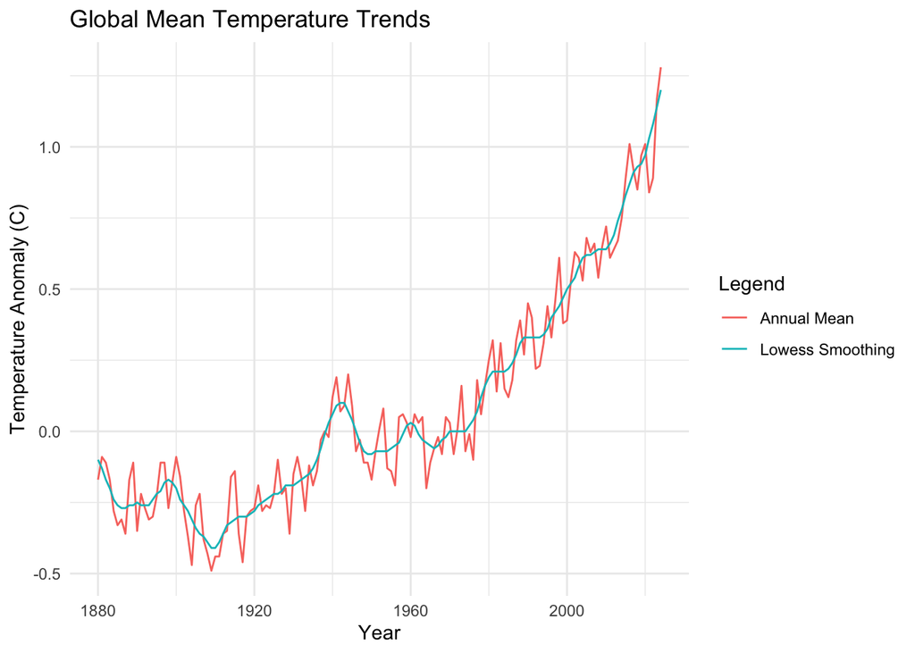

```r
ggplot(climate, aes(x = Year)) +
  geom_line(aes(y = No_Smoothing, color = "Annual Mean")) +
  geom_line(aes(y = Lowess_5, color = "Lowess Smoothing")) +
  labs(title = "Global Mean Temperature Trends",
       x = "Year", y = "Temperature Anomaly (C)",
       color = "Legend") +
  theme_minimal()
```

When looking at the plot, it is clear that temperatures overall have been throughout the years since 1880. The first time the temperature anomaly reached 0 for the time in 1938, and it first became positive in 1940. In the early to mid 1960s, the temperature anomaly began a rise that continued until 2024. The 10 most recent years are the warmest years on record, which goes to show just how much the Earth has been heating up as of recently, and throughout history.

## Evaluating the evidence for a “Pause” in warming?

The [2013 IPCC Report](https://www.ipcc.ch/pdf/assessment-report/ar5/wg1/WG1AR5_SummaryVolume_FINAL.pdf) included a tentative observation of a “much smaller increasing trend” in global mean temperatures since 1998 than was observed previously. This led to much discussion in the media about the existence of a “Pause” or “Hiatus” in global warming rates, as well as much research looking into where the extra heat could have gone. (Examples discussing this question include articles in [The Guardian](http://www.theguardian.com/environment/2015/jun/04/global-warming-hasnt-paused-study-finds), [BBC News](http://www.bbc.com/news/science-environment-28870988), and [Wikipedia](https://en.wikipedia.org/wiki/Global_warming_hiatus)).

You will use rolling averages to help you explore the evidence for a pause. Since you have not been provided instructions for calculating rolling means, the learning objective of this question is to practice finding the solution.

**Question 6:**

Use a search engine (e.g., Google) or a chat LLM to find out how to calculate a rolling average in R. What search term or chat LLM prompt did you use? What website or answer from the chat LLM did you end up using? How much did you need to modify the code from the website or chat LLM to answer the question successfully?

**Answer 6:**

In order to calculate a rolling average in R, you must use the rollmean() function. I simply looked up on Google “how do you calculate a rolling average in R” and this was the first response under the “AI Overview” tab. It advised me that list function uses the “zoo” package and is formatted like so rollmean(your_data, k = window_size, fill = NA, align = “right”). I have to modify the code to include my data the desired window size, the fill, and the allignment. **Question 7:**

- What is the meaning of “5-year average” vs. “annual average”?
- Create a data frame from the annual temperature anomaly data (from Question 4) with three new columns: 5-year running averages, 10-year running averages, and 20-year running averages.

**Answer 7:**

The annual average is the average temperature anomaly for a single year. A 5-year average is the average temperature anomalies over a 5 year period, or window.

```r
library(zoo)

climate <- read_table("https://data.giss.nasa.gov/gistemp/graphs/graph_data/Global_Mean_Estimates_based_on_Land_and_Ocean_Data/graph.txt",
                   skip = 5,
                   col_names = c("Year", "No_Smoothing", "Lowess_5"),
                   na = c("-1", "-99.99"))

climate$Rolling_5 <- rollmean(climate$No_Smoothing, k = 5, fill = NA, align = "right")
climate$Rolling_10 <- rollmean(climate$No_Smoothing, k = 10, fill = NA, align = "right")
climate$Rolling_20 <- rollmean(climate$No_Smoothing, k = 20, fill = NA, align = "right")

climate
```

```
# A tibble: 145 × 6
    Year No_Smoothing Lowess_5 Rolling_5 Rolling_10 Rolling_20
   <dbl>        <dbl>    <dbl>     <dbl>      <dbl>      <dbl>
 1  1880        -0.17    -0.1     NA          NA            NA
 2  1881        -0.09    -0.13    NA          NA            NA
 3  1882        -0.11    -0.17    NA          NA            NA
 4  1883        -0.17    -0.2     NA          NA            NA
 5  1884        -0.28    -0.24    -0.164      NA            NA
 6  1885        -0.33    -0.26    -0.196      NA            NA
 7  1886        -0.31    -0.27    -0.24       NA            NA
 8  1887        -0.36    -0.27    -0.29       NA            NA
 9  1888        -0.17    -0.26    -0.29       NA            NA
10  1889        -0.11    -0.26    -0.256      -0.21         NA
# ℹ 135 more rows
```

**Question 8:**

Plot the different averages on the *same plot* and describe what differences you see and why.

**Answer 8:**

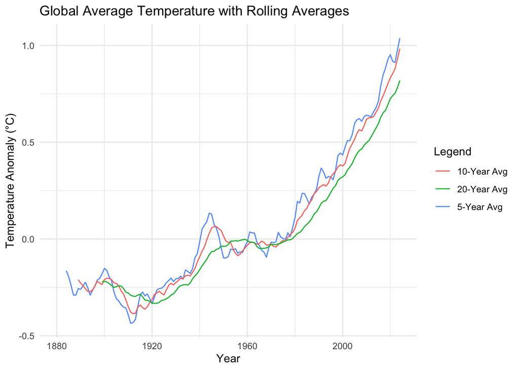

```r
ggplot(climate, aes(x = Year)) +
  geom_line(aes(y = Rolling_5, color = "5-Year Avg")) +
  geom_line(aes(y = Rolling_10, color = "10-Year Avg")) +
  geom_line(aes(y = Rolling_20, color = "20-Year Avg")) +
  labs(title = "Global Average Temperature with Rolling Averages",
       x = "Year", y = "Temperature Anomaly (°C)",
       color = "Legend") +
  theme_minimal()
```

The first thing I notice about this graph above is that the 5-year average line seems to be much more jagged and there appears to be more fluctuation in the temperature anomalies than the 10 and 20-year averages. The 20-year average line appears much more rounded and smooth. This makes sense as the 20-year data is averaging 20 different yearly temperatures so there would be less variation in the points along the graph. This also explains why the 5-year average line appears much more jagged, as there is only a 5 year average which could more heavily factor in outliers, or trends in a short period.

**Question 9:**

By examining the data here, what evidence do you find or not find for such a pause?

**Answer 9:**

When looking at this graph, in particular the 20-year rolling average line, it becomes clear that there is no pause, or hiatus in global warming. The temperature anomaly has been steadily increasing since the late 1960s and early 1970s. Seeing how smooth the 20-year average line is just shows how steadily the temperature has been increasing without pauses or breaks in the warming. Overall, there might be slight declines in average temperature per year due to weather anomalies or extreme years, but at the current rate we are progressing, there not seem to be any pauses, or breaks in global warming anytime soon.